```python
%matplotlib inline
```

```python
import pandas as pd
import matplotlib.pyplot as plt
import seaborn as sns
import numpy as np
from plotly.offline import download_plotlyjs, init_notebook_mode, plot, iplot
import cufflinks as cf
cf.go_offline()
cf.set_config_file(offline=False, world_readable=True)
import plotly.graph_objs as go
from IPython.display import IFrame
from sklearn.linear_model import LinearRegression
from IPython.display import Image
```

# The best state in USA to invest in beekeeping as a business

## Vladimir Milslavov Mikov

### Abstract

We all know how important are bees to us and to our planet. As peoples destructive actions on nature, increase the danger of losing the most important pollinator on the planet. This would destroy ecosystem balance with incredible consequences. Everyone knows. This project will analyze data that could determine which state in USA would be best for a long-term investment in beekeeping, We will consider not only by yield per colony, but also by the price of honey, the economic index and the use of pesticides. Providing a reasonable investment for the staff and making informed choices about investing in such a noble cause.This research use interactive visualization!

[figure not shown]

### 1.Introduction

**Kingdom** Animalia  
**Phylum** Arthropoda  
**Class** Insecta  
**Order** Hymenoptera  
**Family** Apiidae  
**Genus** Apis  
**Species Apis** mellifera

**This is а honeybee!**

Honey bees are big money makers for U.S. agriculture. These social and hardworking insects produce six hive products – honey, pollen, royal jelly, beeswax, propolis, and venom – all collected and used by people for various nutritional and medicinal purposes.

Honey, of course, is the most well-known and economically important hive product. According to the U.S. Department of Agriculture’s National Agriculture Statistics Service, honey bees made a little less than 163 million pounds of honey in 2016. With the cost of honey around 2,08 \$ per pound, that’s a value of a little over $339 million.

After honey, beeswax is the second most important hive product from an economic standpoint. The beeswax trade dates to ancient Greece and Rome, and in Medieval Europe, the substance was a unit of trade for taxes and other purposes. The market remains strong today. Beeswax is popular for making candles and as an ingredient in artists’ materials and in leather and wood polishes. The pharmaceutical industry uses the substance as a binding agent, time-release mechanism, and drug carrier. Beeswax is also one of the most commonly used waxes in cosmetics. The U.S. is a major producer of raw beeswax, as well as a worldwide supplier of refined beeswax.

But the greatest importance of honey bees to agriculture isn’t a product of the hive at all. It’s their work as crop pollinators. This agricultural benefit of honey bees is estimated to be between 10 and 20 times the total value of honey and beeswax. In fact, bee pollination accounts for about $15 billion in added crop value. Honey bees are like flying dollar bills buzzing over U.S. crops.[2]

Classification and Origin of Honeybees Honeybees have been classified as follows:[3]

### Types of bees in hive

|  | Queen | Drone | Worker |
| --- | --- | --- | --- |
| **relative size** | large | medium | small |
| **hive** | 1 | ~200 or 0 | 20K-200K |
| **lifespan** | 2 years depending on sperm | 21-32 days spring 90 days summer or until mating 0 winter | 20-40 days summer (worked to death) 140 days winter |
| **sex** | female/bisexual | male | sterile female |
| **functions** | kill sisters and mother, mate with males, lay 1500 eggs/day = 200K eggs/year, secrete pheromone = 9-hydroxydecenoic acid HOOC=C-C-C-C-C-C-COH-C | mate with young queen | make comb -tend larvae -tend young drones -tend queen -clean hive -gather nectar -gather pollen -gather propolis -evaporate nectar -cap cells -defend hive -starve drones -lay drone eggs -move larvae f… |

A nice story represent "The great honeybee migration in USA". There is a link in References [4] :)

### 2. Obtaining and clean the necessary data

### 2.1 Collecting data

• **yieldpercol**: Honey yield per colony. Unit is pounds

• **totalprod**: Total production (numcol x yieldpercol). Unit is pounds

• **stocks**: Refers to stocks held by producers. Unit is pounds

• **priceperlb**: Refers to average price per pound based on expanded sales. Unit is dollars.

• **prodvalue**: Value of production (totalprod x priceperlb). Unit is dollars.

From USGS Data

• **nCLOTHIANIDIN**: The amount in kg of CLOTHIANIDIN applied

• **nIMIDACLOPRID**: The amount in kg of IMIDACLOPRID applied

• **nTHIAMETHOXAM**: The amount in kg of THIAMETHOXAM applied

• **nACETAMIPRID**: The amount in kg of ACETAMIPRID applied

• **nTHIACLOPRID**: The amount in kg of THIACLOPRID applied

• **nAllNeonic**: The amount in kg of all Neonics applied = (nCLOTHIANIDIN + nIMIDACLOPRID + nTHIAMETHOXAM + nACETAMIPRID + nTHIACLOPRID)

[5]

```python
bees_data = pd.read_csv('vHoneyNeonic_v03.csv')
```

```python
bees_data.head()
```

|  | state | numcol | yieldpercol | totalprod | stocks | priceperlb | prodvalue | year | StateName | Region | FIPS | nCLOTHIANIDIN | nIMIDACLOPRID | nTHIAMETHOXAM | nACETAMIPRID | nTHIACLOPRID | nAllNeonic |
| --- | --- | --- | --- | --- | --- | --- | --- | --- | --- | --- | --- | --- | --- | --- | --- | --- | --- |
| 0 | AL | 14000.0 | 66 | 924000.0 | 92000.0 | 0.81 | 748000.0 | 1997 | Alabama | South | 1 | 0.0 | 6704.8 | 0.0 | 0.0 | 0.0 | 6704.8 |
| 1 | AL | 15000.0 | 64 | 960000.0 | 96000.0 | 0.87 | 835000.0 | 1996 | Alabama | South | 1 | 0.0 | 371.6 | 0.0 | 0.0 | 0.0 | 371.6 |
| 2 | AL | 16000.0 | 58 | 928000.0 | 28000.0 | 0.69 | 640000.0 | 1995 | Alabama | South | 1 | 0.0 | 716.5 | 0.0 | 0.0 | 0.0 | 716.5 |
| 3 | AL | 18000.0 | 50 | 900000.0 | 99000.0 | 0.52 | 468000.0 | 1994 | Alabama | South | 1 | NaN | NaN | NaN | NaN | NaN | NaN |
| 4 | AL | 19000.0 | 45 | 855000.0 | 103000.0 | 0.59 | 504000.0 | 1993 | Alabama | South | 1 | NaN | NaN | NaN | NaN | NaN | NaN |

```python
'''
Check for null values
'''
bees_data.isnull().sum()
```

```
state              0
numcol             0
yieldpercol        0
totalprod          0
stocks             0
priceperlb         0
prodvalue          0
year               0
StateName          0
Region             0
FIPS               0
nCLOTHIANIDIN    237
nIMIDACLOPRID    237
nTHIAMETHOXAM    237
nACETAMIPRID     237
nTHIACLOPRID     237
nAllNeonic       237
dtype: int64
```

```python
'''
Fill NaN with 0
'''
bees_data = bees_data.fillna(0)
```

```python
bees_data.shape
```

```
(1132, 17)
```

```python
bees_data.info()
```

```
<class 'pandas.core.frame.DataFrame'>
RangeIndex: 1132 entries, 0 to 1131
Data columns (total 17 columns):
state            1132 non-null object
numcol           1132 non-null float64
yieldpercol      1132 non-null int64
totalprod        1132 non-null float64
stocks           1132 non-null float64
priceperlb       1132 non-null float64
prodvalue        1132 non-null float64
year             1132 non-null int64
StateName        1132 non-null object
Region           1132 non-null object
FIPS             1132 non-null int64
nCLOTHIANIDIN    1132 non-null float64
nIMIDACLOPRID    1132 non-null float64
nTHIAMETHOXAM    1132 non-null float64
nACETAMIPRID     1132 non-null float64
nTHIACLOPRID     1132 non-null float64
nAllNeonic       1132 non-null float64
dtypes: float64(11), int64(3), object(3)
memory usage: 150.5+ KB
```

```python
'''
Change object column in category
'''
for column in ['state', 'StateName', 'Region']:
    bees_data[column] = bees_data[column].astype('category')
```

```python
bees_data.head()
```

|  | state | numcol | yieldpercol | totalprod | stocks | priceperlb | prodvalue | year | StateName | Region | FIPS | nCLOTHIANIDIN | nIMIDACLOPRID | nTHIAMETHOXAM | nACETAMIPRID | nTHIACLOPRID | nAllNeonic |
| --- | --- | --- | --- | --- | --- | --- | --- | --- | --- | --- | --- | --- | --- | --- | --- | --- | --- |
| 0 | AL | 14000.0 | 66 | 924000.0 | 92000.0 | 0.81 | 748000.0 | 1997 | Alabama | South | 1 | 0.0 | 6704.8 | 0.0 | 0.0 | 0.0 | 6704.8 |
| 1 | AL | 15000.0 | 64 | 960000.0 | 96000.0 | 0.87 | 835000.0 | 1996 | Alabama | South | 1 | 0.0 | 371.6 | 0.0 | 0.0 | 0.0 | 371.6 |
| 2 | AL | 16000.0 | 58 | 928000.0 | 28000.0 | 0.69 | 640000.0 | 1995 | Alabama | South | 1 | 0.0 | 716.5 | 0.0 | 0.0 | 0.0 | 716.5 |
| 3 | AL | 18000.0 | 50 | 900000.0 | 99000.0 | 0.52 | 468000.0 | 1994 | Alabama | South | 1 | 0.0 | 0.0 | 0.0 | 0.0 | 0.0 | 0.0 |
| 4 | AL | 19000.0 | 45 | 855000.0 | 103000.0 | 0.59 | 504000.0 | 1993 | Alabama | South | 1 | 0.0 | 0.0 | 0.0 | 0.0 | 0.0 | 0.0 |

### Read another data for cost of living in USA.

Used data set from Kaggle.com named "Cost of Living Index by Cities".Cost of living indices are relative to New York City (NYC) which means that for New York City, each index should be 100. If another city has, for example, rent index of 120, it means that on an average in that city rents are 20% more expensive than in New York City. If a city has rent index of 70, that means on an average in that city rents are 30% less expensive than in New York City. **Cost of Living Index** (Excl. Rent) is a relative indicator of consumer goods prices, including groceries, restaurants, transportation and utilities.

**Rent Index** is an estimation of prices of renting apartments in the city compared to New York City.

**Groceries Index** is an estimation of grocery prices in the city compared to New York City.

**Restaurants Index** is a comparison of prices of meals and drinks in restaurants and bars compared to NYC.

**Cost of Living Plus Rent Index** is an estimation of consumer goods prices including rent comparing to New York City.

**Local Purchasing Power** shows relative purchasing power in buying goods and services in a given city for the average wage in that city. [6]

```python
living_cost = pd.read_csv('Cost_of_living_index.csv')
```

```python
living_cost.head()
```

|  | Rank | City | Cost of Living Index | Rent Index | Cost of Living Plus Rent Index | Groceries Index | Restaurant Price Index | Local Purchasing Power Index |
| --- | --- | --- | --- | --- | --- | --- | --- | --- |
| 0 | 1 | Hamilton, Bermuda | 137.56 | 103.03 | 121.21 | 126.56 | 151.77 | 114.19 |
| 1 | 2 | Zurich, Switzerland | 128.65 | 62.62 | 97.39 | 127.35 | 127.14 | 142.39 |
| 2 | 3 | Basel, Switzerland | 126.89 | 46.14 | 88.66 | 120.44 | 129.10 | 141.48 |
| 3 | 4 | Lausanne, Switzerland | 119.62 | 50.35 | 86.83 | 116.35 | 122.83 | 132.58 |
| 4 | 5 | Bern, Switzerland | 118.42 | 39.22 | 80.93 | 114.54 | 114.86 | 115.48 |

```python
'''
Split the column City and put City name and state in 2 new columns, that will be use later
'''

living_cost['City_info'] = living_cost['City'].str.split(', ')
living_cost_US = living_cost[living_cost.apply(lambda x:len(list(x['City_info']))==3, axis=1)]
living_cost_US = living_cost[living_cost.apply(lambda x:len(list(x['City_info']))==3, axis=1)]
living_cost_US = living_cost_US.drop('City', axis=1)
living_cost_US.loc[:, 'state'] = living_cost_US.City_info.map(lambda x: x[1])
living_cost_US.loc[:, 'City'] = living_cost_US.City_info.map(lambda x: x[0])
living_cost_US = living_cost_US.drop('City_info', axis=1)
living_cost_US = living_cost_US.reset_index(drop=True)
```

```python
living_cost_US.head()
```

|  | Rank | Cost of Living Index | Rent Index | Cost of Living Plus Rent Index | Groceries Index | Restaurant Price Index | Local Purchasing Power Index | state | City |
| --- | --- | --- | --- | --- | --- | --- | --- | --- | --- |
| 0 | 12 | 100.00 | 100.00 | 100.00 | 100.00 | 100.00 | 100.00 | NY | New York |
| 1 | 14 | 96.88 | 106.49 | 101.43 | 101.93 | 94.58 | 125.95 | CA | San Francisco |
| 2 | 15 | 93.72 | 63.96 | 79.63 | 96.32 | 86.72 | 113.58 | HI | Honolulu |
| 3 | 16 | 93.19 | 39.45 | 67.75 | 96.74 | 78.76 | 138.38 | AK | Anchorage |
| 4 | 17 | 90.31 | 81.02 | 85.91 | 83.16 | 95.27 | 87.05 | NY | Brooklyn |

```python
'''
Check for null values
'''
living_cost.isnull().sum()
```

```
Rank                              0
City                              0
Cost of Living Index              0
Rent Index                        0
Cost of Living Plus Rent Index    0
Groceries Index                   0
Restaurant Price Index            0
Local Purchasing Power Index      0
City_info                         0
dtype: int64
```

```python
living_cost_US.info()
```

```
<class 'pandas.core.frame.DataFrame'>
RangeIndex: 112 entries, 0 to 111
Data columns (total 9 columns):
Rank                              112 non-null int64
Cost of Living Index              112 non-null float64
Rent Index                        112 non-null float64
Cost of Living Plus Rent Index    112 non-null float64
Groceries Index                   112 non-null float64
Restaurant Price Index            112 non-null float64
Local Purchasing Power Index      112 non-null float64
state                             112 non-null object
City                              112 non-null object
dtypes: float64(6), int64(1), object(2)
memory usage: 8.0+ KB
```

```python
'''
We are interesting only on cost of_ iving plus rent index
'''
living_cost_US = living_cost_US[['City','state','Cost of Living Plus Rent Index']]
```

```python
living_cost_US = living_cost_US.rename(columns={"City": "city",
                                                "Cost of Living Plus Rent Index": "cost_of_living_plus_rent_index"})
```

```python
living_cost_US.head()
```

|  | city | state | cost_of_living_plus_rent_index |
| --- | --- | --- | --- |
| 0 | New York | NY | 100.00 |
| 1 | San Francisco | CA | 101.43 |
| 2 | Honolulu | HI | 79.63 |
| 3 | Anchorage | AK | 67.75 |
| 4 | Brooklyn | NY | 85.91 |

### 3. Exploring the data

**3.1 Distribution of the average number of columns in the United States during the period 1991-2017**

```python
'''
Group by state is needed action to present the mean number of colonies per state.
'''
colony_mean_number = bees_data.groupby('state').mean()
```

```python
'''
Rounded all values in dataframe 2 sign after decimal point for better view.
'''
colony_mean_number = colony_mean_number.round(2)
```

```python
colony_mean_number.head()
```

| state | numcol | yieldpercol | totalprod | stocks | priceperlb | prodvalue | year | FIPS | nCLOTHIANIDIN | nIMIDACLOPRID | nTHIAMETHOXAM | nACETAMIPRID | nTHIACLOPRID | nAllNeonic |
| --- | --- | --- | --- | --- | --- | --- | --- | --- | --- | --- | --- | --- | --- | --- |
| AL | 12740.74 | 59.63 | 750703.70 | 115851.85 | 1.57 | 922703.70 | 2004.0 | 1.0 | 1854.83 | 2868.39 | 2165.18 | 0.00 | 0.00 | 6888.39 |
| AR | 37185.19 | 73.30 | 2792814.81 | 836000.00 | 1.13 | 2669592.59 | 2004.0 | 5.0 | 2193.44 | 5865.01 | 9160.74 | 629.92 | 0.00 | 17849.11 |
| AZ | 37333.33 | 58.15 | 2217185.19 | 741962.96 | 1.16 | 2104888.89 | 2004.0 | 4.0 | 341.91 | 7538.03 | 355.41 | 739.71 | 0.00 | 8975.06 |
| CA | 399629.63 | 56.44 | 23524444.44 | 5475074.07 | 1.17 | 22988592.59 | 2004.0 | 6.0 | 6591.80 | 55340.00 | 3680.97 | 8218.37 | 3.18 | 73834.34 |
| CO | 32481.48 | 61.00 | 2018000.00 | 798925.93 | 1.26 | 2196222.22 | 2004.0 | 8.0 | 3425.22 | 1559.94 | 1419.49 | 0.45 | 0.00 | 6405.11 |

```python
'''
For better view colors distributions need customisation.
'''

text = [
    f'Mean price: {price} $'
    for price in colony_mean_number['priceperlb']
]

data = dict(type='choropleth',
            colorscale = [[0.0, "#913442"],
                [0.01, "#AD4040"],
                [0.02, "#C85D4C"],
                [0.03, "#E47F59"],
                [0.04, "#FFA566"],
                [0.05, "#FFB979"],
                [0.06, "#FFCA8C"],
                [0.07, "#FFDAA0"],
                [0.08, "#FFE75B"],
                [0.09, "#FFF2CB"],
                [0.1, "#FFF9E1"],
                [0.15, "#DEEDCF"],
                [0.2, "#BFE1B0"],
                [0.25, "#99D492"],
                [0.3, "#74C67A"],
                [0.35, "#56B870"],
                [0.4, "#39A96B"],
                [0.45, "#1D9A6C"],
                [0.5, "#188977"],
                [0.55, "#137177"],
                [0.6, "#0E4D64"],
                [1.0, "#0A2F51"]],
            locations = colony_mean_number.index,
            z = colony_mean_number['numcol'],
            locationmode = 'USA-states',
            text = text,
            marker = dict(line = dict(color = 'rgb(255,255,255)',width = 1)),
            colorbar = {'title':"Number of colonies"}
            )
```

```python
layout = dict(title = 'Average number of colony and mean price per lb for period 1991-2017',
              geo = dict(scope='usa',
                         showlakes = True,
                         lakecolor = 'rgb(85,173,240)')
             )
```

```python
choromap = go.Figure(data = [data],layout = layout)
```

```python
iplot(choromap)
```

[interactive chart not shown]

We can look at the distribution of the average number of bee colonies in different states with the average price per lb in each state. CA - California has more than 10 times more bee colonies than all states in central America

The research interest is related to finding the most suitable state for investment in a bee farm.

**3.2 Correlation of the number of bee colonies in USA and total production over the years 1991-2017**

```python
bees_by_year = bees_data.groupby('year').sum()
```

```python
'''
Group by year is needed action to present the information over the year
'''
bees_by_year['mean_price'] = bees_data.groupby('year').mean()['priceperlb']
```

```python
bees_by_year['mean_price'] = bees_by_year['mean_price'].round(2)
```

```python
bees_by_year.head()
```

| year | numcol | yieldpercol | totalprod | stocks | priceperlb | prodvalue | FIPS | nCLOTHIANIDIN | nIMIDACLOPRID | nTHIAMETHOXAM | nACETAMIPRID | nTHIACLOPRID | nAllNeonic | mean_price |
| --- | --- | --- | --- | --- | --- | --- | --- | --- | --- | --- | --- | --- | --- | --- |
| 1991 | 3169000.0 | 2608 | 218883000.0 | 36128000.0 | 28.41 | 122813000.0 | 1343 | 0.0 | 0.0 | 0.0 | 0.0 | 0.0 | 0.0 | 0.65 |
| 1992 | 3021000.0 | 2716 | 220349000.0 | 38870000.0 | 28.25 | 122000000.0 | 1343 | 0.0 | 0.0 | 0.0 | 0.0 | 0.0 | 0.0 | 0.64 |
| 1993 | 2868000.0 | 2995 | 230444000.0 | 48830000.0 | 29.03 | 124646000.0 | 1343 | 0.0 | 0.0 | 0.0 | 0.0 | 0.0 | 0.0 | 0.66 |
| 1994 | 2764000.0 | 2976 | 216968000.0 | 59699000.0 | 28.75 | 115848000.0 | 1343 | 0.0 | 11207.2 | 0.0 | 0.0 | 0.0 | 11207.2 | 0.65 |
| 1995 | 2640000.0 | 2944 | 210278000.0 | 42122000.0 | 34.58 | 145235000.0 | 1343 | 0.0 | 82134.0 | 0.0 | 0.0 | 0.0 | 82134.0 | 0.79 |

```python
text = [
    f'Mean price: {price} $'
    for price in bees_by_year['mean_price']
]
bees_by_year[['numcol', 'mean_price', 'totalprod']].iplot(
    y='numcol', mode='lines+markers', secondary_y = 'totalprod',
    secondary_y_title='Total production', xTitle='Year', yTitle='Number of colonies',
    text= text ,title='Number of colonies and total production in USA 1991-2017', legend=dict(x=0.9, y=1.1))
```

[interactive chart not shown]

We can see as values the number of all colonies in the United States, the amount of production. Interactive information shows the average price of production for each year.

With the decrease in the number of bee colonies in the early 1990s, we can see the average yield look very good , which on the basis of these data could make the conclusion that grazing was fully utilized. This is also the reason for high-yields while reducing bee families. This chart behavior is also believed to be possible due that the entry of pollination as a service in the US (Bee families are transported to different locations where they improve crop pollination and get paid. As a result of monocultural planting, we can observe a decrease in the quality and diversity of food stocks, which decreases their immune system and this affects their quality of life..

It is noticed that there is a tendency to decrease both :the total production and the number of bee families in the USA, but let's see how the quantity of production, produced by one bee colony, changes over the years.

**3.3 Functional dependency between number of colonies and average yield per colony in USA 1991-2017'**

```python
bees_yield_mean = bees_data.groupby('year').mean()
```

```python
bees_yield_mean['colony_sum'] = bees_data.groupby('year').sum()['numcol']
```

```python
bees_yield_mean.head()
```

| year | numcol | yieldpercol | totalprod | stocks | priceperlb | prodvalue | FIPS | nCLOTHIANIDIN | nIMIDACLOPRID | nTHIAMETHOXAM | nACETAMIPRID | nTHIACLOPRID | nAllNeonic | colony_sum |
| --- | --- | --- | --- | --- | --- | --- | --- | --- | --- | --- | --- | --- | --- | --- |
| 1991 | 72022.727273 | 59.272727 | 4.974614e+06 | 8.210909e+05 | 0.645682 | 2.791205e+06 | 30.522727 | 0.0 | 0.000000 | 0.0 | 0.0 | 0.0 | 0.000000 | 3169000.0 |
| 1992 | 68659.090909 | 61.727273 | 5.007932e+06 | 8.834091e+05 | 0.642045 | 2.772727e+06 | 30.522727 | 0.0 | 0.000000 | 0.0 | 0.0 | 0.0 | 0.000000 | 3021000.0 |
| 1993 | 65181.818182 | 68.068182 | 5.237364e+06 | 1.109773e+06 | 0.659773 | 2.832864e+06 | 30.522727 | 0.0 | 0.000000 | 0.0 | 0.0 | 0.0 | 0.000000 | 2868000.0 |
| 1994 | 62818.181818 | 67.636364 | 4.931091e+06 | 1.356795e+06 | 0.653409 | 2.632909e+06 | 30.522727 | 0.0 | 254.709091 | 0.0 | 0.0 | 0.0 | 254.709091 | 2764000.0 |
| 1995 | 60000.000000 | 66.909091 | 4.779045e+06 | 9.573182e+05 | 0.785909 | 3.300795e+06 | 30.522727 | 0.0 | 1866.681818 | 0.0 | 0.0 | 0.0 | 1866.681818 | 2640000.0 |

```python
text = [
    f'Mean price: {price} $'
    for price in bees_by_year['mean_price']
]
bees_yield_mean[['colony_sum', 'totalprod', 'yieldpercol']].iplot(
    y='colony_sum', mode='lines+markers', secondary_y = 'yieldpercol',
    secondary_y_title='Total production', xTitle='Year', yTitle='Number of colonies',
    text= text ,title='Functional dependency between number of colonies and average yield per colony in USA 1991-2017',
    legend=dict(x=0.9, y=1.1))
```

[interactive chart not shown]

There is interesting behavior of the average yield throughout over the years. An increase in bee colonies over the previous year has seen a decrease in the average yield next year, which is expected given the fact that colonies need to be reduction their force to create new ones.An interesting part of the graph is the period after 2010, when the number of families is increasing, but average yield falling, and I believe that is because a huge percentage of bee families start to use as pollinators against payment by farmers.

**3.4 Avarage incom by state**

Create a new column in dataset, that will be the average value of earning per colony , as produced at the average cost and average yield per colony

```python
income_mean = bees_data.groupby('year').mean()
income_mean['income_per_colony'] = income_mean['priceperlb']*income_mean['yieldpercol']
```

[figure not shown]

```python
income_mean.plot(y = 'income_per_colony', use_index=True, legend = False)
plt.ylabel('Income in US $')
plt.title('The average income per colony 1992-2008')
plt.show()
```

**3.5 Correlation between yield per colony and the mean price of production**

```python
state_mean_income = bees_data.groupby('state').mean()
```

```python
state_mean_income['mean_income'] = state_mean_income['yieldpercol'] * state_mean_income['priceperlb']
```

```python
state_mean_income.head()
```

| state | numcol | yieldpercol | totalprod | stocks | priceperlb | prodvalue | year | FIPS | nCLOTHIANIDIN | nIMIDACLOPRID | nTHIAMETHOXAM | nACETAMIPRID | nTHIACLOPRID | nAllNeonic | mean_income |
| --- | --- | --- | --- | --- | --- | --- | --- | --- | --- | --- | --- | --- | --- | --- | --- |
| AL | 12740.740741 | 59.629630 | 7.507037e+05 | 1.158519e+05 | 1.570741 | 9.227037e+05 | 2004.0 | 1.0 | 1854.825926 | 2868.385185 | 2165.177778 | 0.000000 | 0.000000 | 6888.388889 | 93.662689 |
| AR | 37185.185185 | 73.296296 | 2.792815e+06 | 8.360000e+05 | 1.132963 | 2.669593e+06 | 2004.0 | 5.0 | 2193.440741 | 5865.007407 | 9160.740741 | 629.922222 | 0.000000 | 17849.111111 | 83.041989 |
| AZ | 37333.333333 | 58.148148 | 2.217185e+06 | 7.419630e+05 | 1.155185 | 2.104889e+06 | 2004.0 | 4.0 | 341.907407 | 7538.025926 | 355.414815 | 739.714815 | 0.000000 | 8975.062963 | 67.171879 |
| CA | 399629.629630 | 56.444444 | 2.352444e+07 | 5.475074e+06 | 1.169259 | 2.298859e+07 | 2004.0 | 6.0 | 6591.803704 | 55340.003704 | 3680.974074 | 8218.374074 | 3.181481 | 73834.337037 | 65.998189 |
| CO | 32481.481481 | 61.000000 | 2.018000e+06 | 7.989259e+05 | 1.258148 | 2.196222e+06 | 2004.0 | 8.0 | 3425.218519 | 1559.944444 | 1419.492593 | 0.451852 | 0.000000 | 6405.107407 | 76.747037 |

```python
text = [
    f'State: {index}'
    for index in state_mean_income.index
]

state_mean_income.iplot(
    x='yieldpercol',
    y='priceperlb',
    opacity=2,
    size=state_mean_income['mean_income']/4,
    text=text,
    mode='markers',
    theme='pearl',
    layout=dict(
        xaxis=dict(type='log', title='Yield per colony'),
        yaxis=dict(title='Price per lb'),
        title='Correlation between yield per colony and the mean price of production'))
```

[interactive chart not shown]

Interactive graph can show very good with size how big is mean income per colony. There is a states with good yield but the price is not good.We easy see that the winner is Hawaii. Let take best 5 state by mean income.

**3.6 Average income of Top 5 state with best income for period 1991-2017**

```python
pd.__version__
```

```
'0.25.0'
```

```python
'''
For execute this code we need pandas version 0.25.0
Generate the data after apply aggregate function over the columns.
'''

best_state = bees_data.groupby("state").agg(
    mean_yield_per_col=pd.NamedAgg(column='yieldpercol', aggfunc=np.mean),
    mean_price_per_lb=pd.NamedAgg(column='priceperlb', aggfunc=np.mean)
   )
```

```python
best_state['income'] = best_state.mean_yield_per_col*best_state.mean_price_per_lb

best_state = best_state.sort_values(['mean_yield_per_col','mean_price_per_lb'], ascending = [True, True])
best_state = best_state.sort_values(by=['income'], ascending=False)
```

```python
best_5_state = best_state.head(5)
```

```python
best_5_state.head()
```

| state | mean_yield_per_col | mean_price_per_lb | income |
| --- | --- | --- | --- |
| HI | 109.925926 | 1.480741 | 162.771797 |
| IL | 59.888889 | 2.320370 | 138.964403 |
| SC | 69.538462 | 1.924615 | 133.834793 |
| VT | 65.629630 | 1.866296 | 122.484335 |
| TN | 54.444444 | 2.105185 | 114.615638 |

```python
'''
Need to filter data and use only observation for top 5 state with highest avarage income.
'''
states_5 = list(best_5_state.index)
best_5_state = bees_data[bees_data['state'].isin(states_5)]
best_5_state['income'] = best_5_state['yieldpercol'] * best_5_state['priceperlb']
best_5_state = best_5_state.sort_values(by='year')
```

```python
best_5_state.head()
```

|  | state | numcol | yieldpercol | totalprod | stocks | priceperlb | prodvalue | year | StateName | Region | FIPS | nCLOTHIANIDIN | nIMIDACLOPRID | nTHIAMETHOXAM | nACETAMIPRID | nTHIACLOPRID | nAllNeonic | income |
| --- | --- | --- | --- | --- | --- | --- | --- | --- | --- | --- | --- | --- | --- | --- | --- | --- | --- | --- |
| 276 | IL | 21000.0 | 52 | 1092000.0 | 393000.0 | 0.79 | 863000.0 | 1991 | Illinois | Midwest | 17 | 0.0 | 0.0 | 0.0 | 0.0 | 0.0 | 0.0 | 41.08 |
| 1002 | VT | 6000.0 | 75 | 450000.0 | 198000.0 | 0.80 | 360000.0 | 1991 | Vermont | Northeast | 50 | 0.0 | 0.0 | 0.0 | 0.0 | 0.0 | 0.0 | 60.00 |
| 895 | TN | 14000.0 | 38 | 532000.0 | 106000.0 | 0.69 | 367000.0 | 1991 | Tennessee | South | 47 | 0.0 | 0.0 | 0.0 | 0.0 | 0.0 | 0.0 | 26.22 |
| 194 | HI | 10000.0 | 131 | 1310000.0 | 328000.0 | 0.57 | 747000.0 | 1991 | Hawaii | West | 15 | 0.0 | 0.0 | 0.0 | 0.0 | 0.0 | 0.0 | 74.67 |
| 852 | SC | 11000.0 | 61 | 671000.0 | 107000.0 | 0.77 | 517000.0 | 1991 | South Carolina | South | 45 | 0.0 | 0.0 | 0.0 | 0.0 | 0.0 | 0.0 | 46.97 |

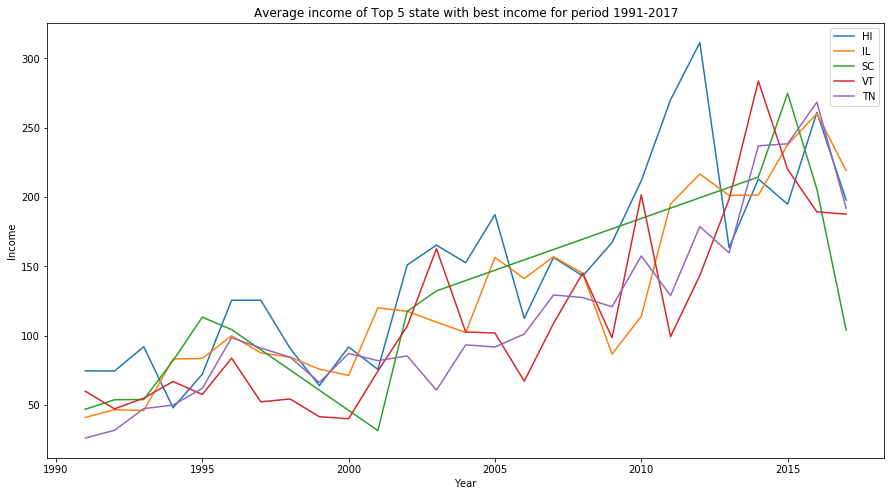

```python
plt.figure(figsize=(15,8))
plt.plot( 'year', 'income', data=best_5_state[best_5_state['state']==states_5[0]],label = states_5[0])
plt.plot( 'year', 'income', data=best_5_state[best_5_state['state']==states_5[1]],label = states_5[1])
plt.plot( 'year', 'income', data=best_5_state[best_5_state['state']==states_5[2]],label = states_5[2])
plt.plot( 'year', 'income', data=best_5_state[best_5_state['state']==states_5[3]],label = states_5[3])
plt.plot( 'year', 'income', data=best_5_state[best_5_state['state']==states_5[4]],label = states_5[4])


plt.xlabel('Year')
plt.ylabel('Income')
plt.title('Average income of Top 5 state with best income for period 1991-2017')
plt.legend()
plt.show()
```

All 5 states show the same trend in increasing profits for one colony. At the end of 2015, there is also interesting big decrease.

**3.7 Index of cost living and correlation between variables**

```python
'''
Deviding by 100 column cost_of_living_plus_rent_index is better for future work
'''
living_cost_US['cost_of_living_plus_rent_index'] = living_cost_US.cost_of_living_plus_rent_index/100
```

```python
living_cost_US = living_cost_US.groupby('state').mean()
```

```python
living_cost_US = living_cost_US.sort_index()
```

```python
best_5_state.head()
```

|  | state | numcol | yieldpercol | totalprod | stocks | priceperlb | prodvalue | year | StateName | Region | FIPS | nCLOTHIANIDIN | nIMIDACLOPRID | nTHIAMETHOXAM | nACETAMIPRID | nTHIACLOPRID | nAllNeonic | income |
| --- | --- | --- | --- | --- | --- | --- | --- | --- | --- | --- | --- | --- | --- | --- | --- | --- | --- | --- |
| 276 | IL | 21000.0 | 52 | 1092000.0 | 393000.0 | 0.79 | 863000.0 | 1991 | Illinois | Midwest | 17 | 0.0 | 0.0 | 0.0 | 0.0 | 0.0 | 0.0 | 41.08 |
| 1002 | VT | 6000.0 | 75 | 450000.0 | 198000.0 | 0.80 | 360000.0 | 1991 | Vermont | Northeast | 50 | 0.0 | 0.0 | 0.0 | 0.0 | 0.0 | 0.0 | 60.00 |
| 895 | TN | 14000.0 | 38 | 532000.0 | 106000.0 | 0.69 | 367000.0 | 1991 | Tennessee | South | 47 | 0.0 | 0.0 | 0.0 | 0.0 | 0.0 | 0.0 | 26.22 |
| 194 | HI | 10000.0 | 131 | 1310000.0 | 328000.0 | 0.57 | 747000.0 | 1991 | Hawaii | West | 15 | 0.0 | 0.0 | 0.0 | 0.0 | 0.0 | 0.0 | 74.67 |
| 852 | SC | 11000.0 | 61 | 671000.0 | 107000.0 | 0.77 | 517000.0 | 1991 | South Carolina | South | 45 | 0.0 | 0.0 | 0.0 | 0.0 | 0.0 | 0.0 | 46.97 |

```python
living_cost_US.head()
```

| state | cost_of_living_plus_rent_index |
| --- | --- |
| AK | 0.67750 |
| AL | 0.49510 |
| AR | 0.45335 |
| AZ | 0.47170 |
| BC | 0.45880 |

```python
'''
Merge two dataframes on state
'''

best_5_state = best_5_state.merge(living_cost_US,on='state',how='left')
```

```python
best_5_state.head()
```

|  | state | numcol | yieldpercol | totalprod | stocks | priceperlb | prodvalue | year | StateName | Region | FIPS | nCLOTHIANIDIN | nIMIDACLOPRID | nTHIAMETHOXAM | nACETAMIPRID | nTHIACLOPRID | nAllNeonic | income | cost_of_living_plus_rent_index |
| --- | --- | --- | --- | --- | --- | --- | --- | --- | --- | --- | --- | --- | --- | --- | --- | --- | --- | --- | --- |
| 0 | IL | 21000.0 | 52 | 1092000.0 | 393000.0 | 0.79 | 863000.0 | 1991 | Illinois | Midwest | 17 | 0.0 | 0.0 | 0.0 | 0.0 | 0.0 | 0.0 | 41.08 | 0.579450 |
| 1 | VT | 6000.0 | 75 | 450000.0 | 198000.0 | 0.80 | 360000.0 | 1991 | Vermont | Northeast | 50 | 0.0 | 0.0 | 0.0 | 0.0 | 0.0 | 0.0 | 60.00 | 0.598700 |
| 2 | TN | 14000.0 | 38 | 532000.0 | 106000.0 | 0.69 | 367000.0 | 1991 | Tennessee | South | 47 | 0.0 | 0.0 | 0.0 | 0.0 | 0.0 | 0.0 | 26.22 | 0.500375 |
| 3 | HI | 10000.0 | 131 | 1310000.0 | 328000.0 | 0.57 | 747000.0 | 1991 | Hawaii | West | 15 | 0.0 | 0.0 | 0.0 | 0.0 | 0.0 | 0.0 | 74.67 | 0.796300 |
| 4 | SC | 11000.0 | 61 | 671000.0 | 107000.0 | 0.77 | 517000.0 | 1991 | South Carolina | South | 45 | 0.0 | 0.0 | 0.0 | 0.0 | 0.0 | 0.0 | 46.97 | 0.577950 |

```python
print(f"Max cost of living index = {best_5_state['cost_of_living_plus_rent_index'].max()}")
print(f"Min cost of living index = {best_5_state['cost_of_living_plus_rent_index'].min()}")
```

```
Max cost of living index = 0.7963
Min cost of living index = 0.500375
```

We can see that all of index is smaller than 1

To show the real difference in the value of income per colony, depending on the living cost index.We can use the formula down below.

$$I_c = I_r*(2-L^i) $$

Where $I_c$ is Corect with cost of living index income, $I_r$ is real income $L^i$ cost of living plus rent index

This action chages the value of income, but give a real information of cost of living tendention,if you live were is your buisness or pay for workers.

```python
best_5_state.loc[best_5_state['cost_of_living_plus_rent_index'] <1 ,
                 'real_value'] = best_5_state['income']*(2 - best_5_state['cost_of_living_plus_rent_index'])
```

```python
best_5_state.head()
```

|  | state | numcol | yieldpercol | totalprod | stocks | priceperlb | prodvalue | year | StateName | Region | FIPS | nCLOTHIANIDIN | nIMIDACLOPRID | nTHIAMETHOXAM | nACETAMIPRID | nTHIACLOPRID | nAllNeonic | income | cost_of_living_plus_rent_index | real_value |
| --- | --- | --- | --- | --- | --- | --- | --- | --- | --- | --- | --- | --- | --- | --- | --- | --- | --- | --- | --- | --- |
| 0 | IL | 21000.0 | 52 | 1092000.0 | 393000.0 | 0.79 | 863000.0 | 1991 | Illinois | Midwest | 17 | 0.0 | 0.0 | 0.0 | 0.0 | 0.0 | 0.0 | 41.08 | 0.579450 | 58.356194 |
| 1 | VT | 6000.0 | 75 | 450000.0 | 198000.0 | 0.80 | 360000.0 | 1991 | Vermont | Northeast | 50 | 0.0 | 0.0 | 0.0 | 0.0 | 0.0 | 0.0 | 60.00 | 0.598700 | 84.078000 |
| 2 | TN | 14000.0 | 38 | 532000.0 | 106000.0 | 0.69 | 367000.0 | 1991 | Tennessee | South | 47 | 0.0 | 0.0 | 0.0 | 0.0 | 0.0 | 0.0 | 26.22 | 0.500375 | 39.320167 |
| 3 | HI | 10000.0 | 131 | 1310000.0 | 328000.0 | 0.57 | 747000.0 | 1991 | Hawaii | West | 15 | 0.0 | 0.0 | 0.0 | 0.0 | 0.0 | 0.0 | 74.67 | 0.796300 | 89.880279 |
| 4 | SC | 11000.0 | 61 | 671000.0 | 107000.0 | 0.77 | 517000.0 | 1991 | South Carolina | South | 45 | 0.0 | 0.0 | 0.0 | 0.0 | 0.0 | 0.0 | 46.97 | 0.577950 | 66.793689 |

```python
best_5_state.describe().T
```

|  | count | mean | std | min | 25% | 50% | 75% | max |
| --- | --- | --- | --- | --- | --- | --- | --- | --- |
| numcol | 121.0 | 8.231405e+03 | 3048.935144 | 3000.000000 | 6000.000000 | 8000.00000 | 9.000000e+03 | 2.100000e+04 |
| yieldpercol | 121.0 | 7.215702e+01 | 27.023141 | 34.000000 | 53.000000 | 64.00000 | 8.300000e+01 | 1.770000e+02 |
| totalprod | 121.0 | 6.042645e+05 | 338255.592922 | 153000.000000 | 357000.000000 | 483000.00000 | 7.840000e+05 | 1.808000e+06 |
| stocks | 121.0 | 1.539917e+05 | 128368.836812 | 8000.000000 | 71000.000000 | 116000.00000 | 2.110000e+05 | 1.020000e+06 |
| priceperlb | 121.0 | 1.941157e+00 | 1.250890 | 0.480000 | 0.930000 | 1.51000 | 2.500000e+00 | 5.420000e+00 |
| prodvalue | 121.0 | 1.040397e+06 | 754368.339289 | 221000.000000 | 574000.000000 | 785000.00000 | 1.260000e+06 | 4.176000e+06 |
| year | 121.0 | 2.003810e+03 | 8.049135 | 1991.000000 | 1997.000000 | 2003.00000 | 2.011000e+03 | 2.017000e+03 |
| FIPS | 121.0 | 3.361983e+01 | 15.963634 | 15.000000 | 17.000000 | 45.00000 | 4.700000e+01 | 5.000000e+01 |
| nCLOTHIANIDIN | 121.0 | 1.145794e+04 | 41287.606530 | 0.000000 | 0.000000 | 0.00000 | 3.951000e+02 | 2.784988e+05 |
| nIMIDACLOPRID | 121.0 | 4.883635e+03 | 14799.315687 | 0.000000 | 0.000000 | 72.90000 | 2.954500e+03 | 8.585230e+04 |
| nTHIAMETHOXAM | 121.0 | 3.501041e+03 | 8359.683692 | 0.000000 | 0.000000 | 0.00000 | 7.584000e+02 | 3.856840e+04 |
| nACETAMIPRID | 121.0 | 9.301818e+01 | 270.664918 | 0.000000 | 0.000000 | 0.00000 | 5.070000e+01 | 2.195600e+03 |
| nTHIACLOPRID | 121.0 | 1.133802e+01 | 31.521871 | 0.000000 | 0.000000 | 0.00000 | 0.000000e+00 | 1.680000e+02 |
| nAllNeonic | 121.0 | 1.994698e+04 | 62304.879857 | 0.000000 | 0.000000 | 200.90000 | 3.094900e+03 | 4.030116e+05 |
| income | 121.0 | 1.254348e+02 | 66.016584 | 26.220000 | 74.670000 | 106.80000 | 1.653000e+02 | 3.112500e+02 |
| cost_of_living_plus_rent_index | 121.0 | 6.143275e-01 | 0.104136 | 0.500375 | 0.577950 | 0.57945 | 5.987000e-01 | 7.963000e-01 |
| real_value | 121.0 | 1.725874e+02 | 89.955889 | 39.320167 | 101.384653 | 149.65884 | 2.279635e+02 | 4.024993e+02 |

```python
filtered_corr = best_5_state[['numcol','yieldpercol','priceperlb','year','nAllNeonic','income','real_value']]
```

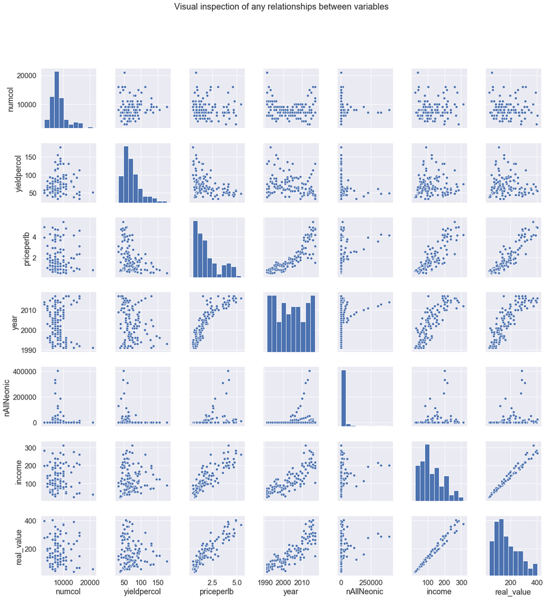

```python
'''
Visual inspection of any relationships between variables show the correlation
between all features.That is useful for analise the data.
'''
sns.set(font_scale=1.5)
f = sns.pairplot(filtered_corr)
f.fig.suptitle("Visual inspection of any relationships between variables", y=1.1, fontsize=20)

plt.show()
```

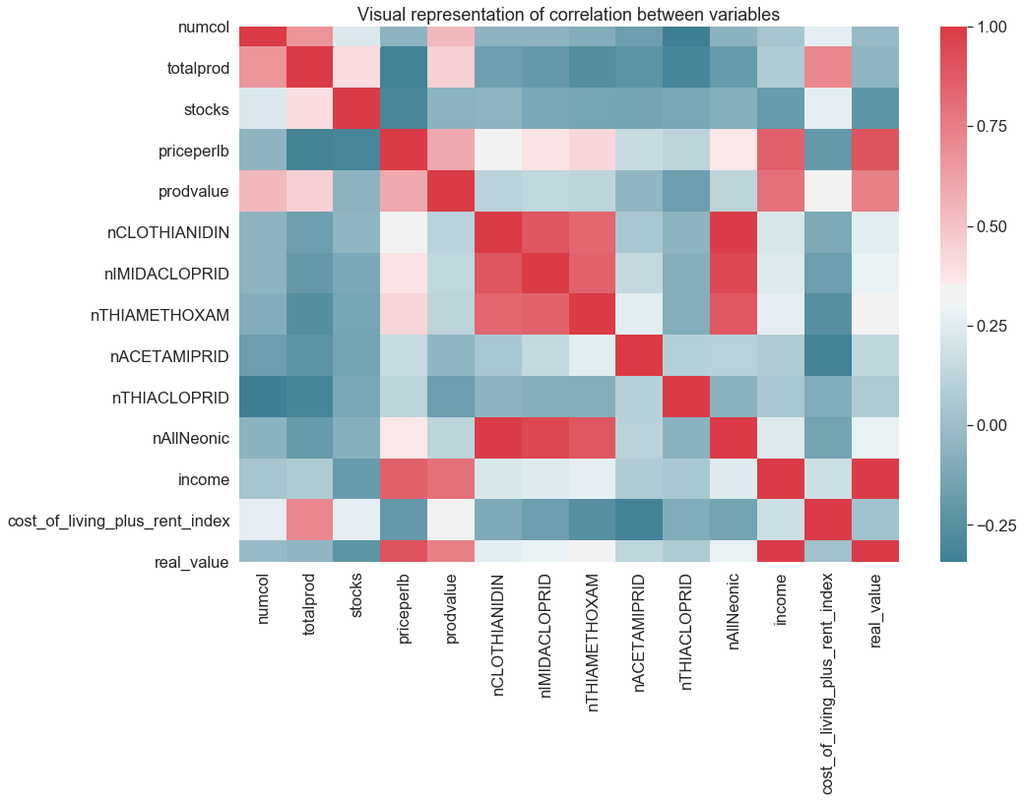

```python
'''
Heatmap to color visualization of correlation between features.
'''

plt.figure(figsize=(15,10))
corr = best_5_state.loc[:,best_5_state.dtypes =='float64'].corr()
sns.heatmap(corr, xticklabels=corr.columns,yticklabels=corr.columns, cmap = sns.diverging_palette(220,10, as_cmap=True))
plt.title('Visual representation of correlation between variables')
plt.show()
```

**3.8 Distribution of used Neonicotinoids in top 5 states**

```python
best_5_state_filtered = best_5_state[['state','nCLOTHIANIDIN','nIMIDACLOPRID','nTHIAMETHOXAM','nACETAMIPRID','nTHIACLOPRID']]
```

```python
best_5_state_filtered = best_5_state_filtered.groupby('state').mean()
```

```python
best_5_state_filtered
```

| state | nCLOTHIANIDIN | nIMIDACLOPRID | nTHIAMETHOXAM | nACETAMIPRID | nTHIACLOPRID |
| --- | --- | --- | --- | --- | --- |
| HI | 0.000000 | 0.000000 | 0.000000 | 0.000000 | 0.000000 |
| IL | 47343.044444 | 15820.577778 | 10052.951852 | 55.585185 | 6.474074 |
| SC | 809.076923 | 1749.553846 | 630.484615 | 8.653846 | 0.000000 |
| TN | 3426.981481 | 5113.903704 | 5260.440741 | 324.270370 | 4.929630 |
| VT | 188.977778 | 109.059259 | 72.892593 | 32.837037 | 39.407407 |

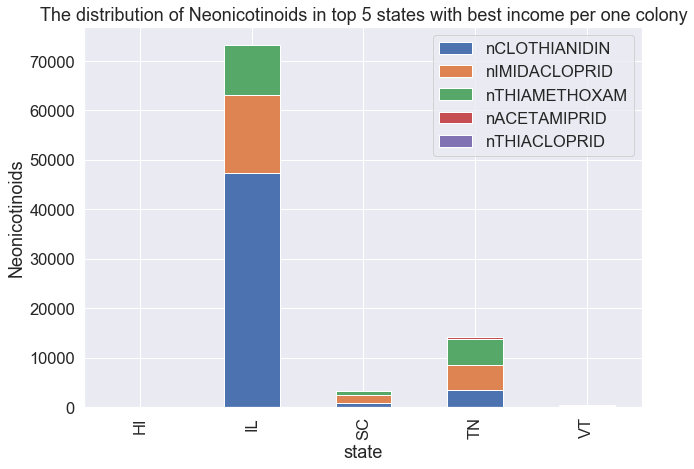

```python
best_5_state_filtered.plot.bar(stacked=True, figsize=(10,7))
plt.ylabel('Neonicotinoids')
plt.title('The distribution of Neonicotinoids in top 5 states with best income per one colony')
plt.show()
```

We can see that Hawaii is different. There are no pesticides to use there, while a significant amount can be seen in Illinois The superiority of one pesticide noted: nCLOTHIANIDIN These are average over 47 tons of pesticides, used per year from the Illinois state. The documentation is in References if there is interest.[7]

**4 Modeling**

```python
  # load data set
X = best_5_state[best_5_state['state']==states_5[0]].iloc[:, 7].values.reshape(-1, 1)  # values converts it into a numpy array
Y = best_5_state[best_5_state['state']==states_5[0]].iloc[:, -1].values.reshape(-1, 1)  # -1 means that calculate the dimension of rows, but have 1 column

linear_regressor = LinearRegression()  # create object for the class
linear_regressor.fit(X, Y)  # perform linear regression
Y_pred = linear_regressor.predict(X)# make predictions
```

```python
def printed(fig,ax,X,Y,Y_pred,state):
    ax.scatter(X, Y, label = state)
    s = ax.plot(X, Y_pred)
```

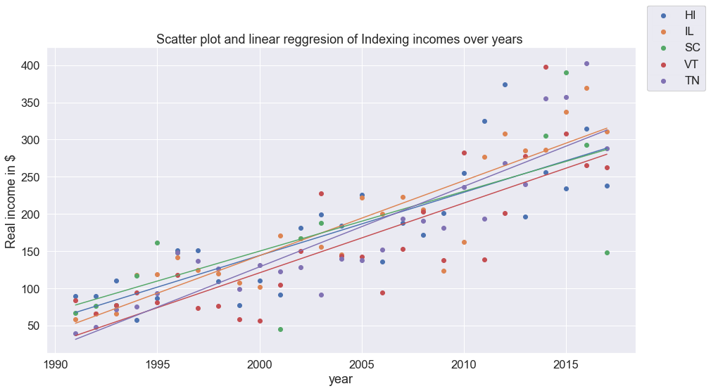

```python
fig, ax = plt.subplots(figsize=[15,8])

for state in states_5:
    X = best_5_state[best_5_state['state']==state].iloc[:, 7].values.reshape(-1, 1)  # values converts it into a numpy array
    Y = best_5_state[best_5_state['state']==state].iloc[:, -1].values.reshape(-1, 1)
    linear_regressor = LinearRegression()  # create object for the class
    linear_regressor.fit(X, Y)  # perform linear regression
    Y_pred = linear_regressor.predict(X)# make predictions
    printed(fig, ax,X,Y,Y_pred,state)
    fig.legend()


ax.set_xlabel("year")
ax.set_ylabel("Real income in $")
plt.title('Scatter plot and linear reggresion of Indexing incomes over years ')
fig.legend()
plt.show()
```

The Illinois state should ensure the best return on future investment, but pesticides used there is a lot , it could be concluded that the best long-term investment option could be any one of The 5 states for different reasons, but I think the smartest choice is Tennessee (TN)

### 5. Conclusions

In conclusion, it could be said that choosing an investment location is not easy because there are many factors that cannot be predicted. From a purely economic point of view, continental states could be much more adaptable because they could benefit from transporting bee colonies long distances, helping to pollinate large monocultural blocks. Although I don't tolerate the monocultural planting of thousands of acres, from an economic point of view it would be the most sensible investment in the continental part of the country. Tennessee (TN),that is a good choice, but you ca think for Hawaii of course :)

```python
Image(url= "https://damontucker.com/wp-content/uploads/2017/03/beekeeper.jpg",width=600, height=600)
```

[figure not shown]

### 4. References

[1] http://www.honeybeecentre.com/learn-about-honeybees#.XUg_FegzZbU

[2] https://www.fda.gov/animal-veterinary/animal-health-literacy/helping-agricultures-helpful-honey-bees

[3] http://www1.biologie.uni-hamburg.de/b-online/ibc99/koning/bees.html

[4] https://www.arcgis.com/apps/Cascade/index.html?appid=34e0fc525ab84493b578228b7a6d8bb1

[5] https://www.kaggle.com/kevinzmith/honey-with-neonic-pesticide

[6] https://www.kaggle.com/debdutta/cost-of-living-index-by-country

[7] https://sitem.herts.ac.uk/aeru/ppdb/en/Reports/171.htm